# (Note)API_HTTP_XML

- Content
  - 資料讀取與匯出
  - 台北市資料大平台OpenData
  - 介紹API
  - 網路通訊協定HTTP
  - XML document
  - 網頁爬蟲 Webscraping

## [台北市資料大平台](https://data.taipei/#/): 以網站上提供的API，用R讀取資料。

除了檔案的資料介面，在網際網路中為了方便傳輸資料，資料在傳遞前都會進行序列化(serialize)，**json、soap、binary和xml**都是經常選擇的格式。

常遇到具有**REST Api Http服務**的資料集提供者，其中json格式大概是目前最常見的選擇，2016這年頭SQL Server也支援json儲存了，未來我們應該有許多機會常和json格式碰到面，今天來複習JSON(JavaScript Object Notation)格式載入。

### 臺北市公有零售市場行情

- 主要欄位說明: 日期,種類,市場,品名,平均(元/公斤)

```r
# install.packages("jsonlite")
library(jsonlite)
data_json <- fromJSON("https://data.taipei/opendata/datalist/apiAccess?scope=resourceAquire&rid=f4f80730-df59-44f9-bfb8-32c136b1ae68")
str(data_json)
```

```
## List of 1
##  $ result:List of 5
##   ..$ limit  : int 1000
##   ..$ offset : int 0
##   ..$ count  : int 24474
##   ..$ sort   : chr ""
##   ..$ results:'data.frame':  1000 obs. of  6 variables:
##   .. ..$  平均(元 / 公斤): chr [1:1000] "61.33" "70.00" "380.00" "45.00" ...
##   .. ..$  品名           : chr [1:1000] "蘿蔔" "胡蘿蔔" "青蔥                                              " "蕹菜(空心菜)                                              " ...
##   .. ..$  市場           : chr [1:1000] "士東" "士東" "士東" "士東" ...
##   .. ..$ 日期            : chr [1:1000] "2019-01-01" "2019-01-01" "2019-01-01" "2019-01-01" ...
##   .. ..$  種類           : chr [1:1000] "蔬菜" "蔬菜" "蔬菜" "蔬菜" ...
##   .. ..$ _id             : int [1:1000] 1 2 3 4 5 6 7 8 9 10 ...
```

```r
data <- data_json[["result"]] [["results"]]
str(data)
```

```
## 'data.frame':    1000 obs. of  6 variables:
##  $  平均(元 / 公斤): chr  "61.33" "70.00" "380.00" "45.00" ...
##  $  品名           : chr  "蘿蔔" "胡蘿蔔" "青蔥                                              " "蕹菜(空心菜)                                              " ...
##  $  市場           : chr  "士東" "士東" "士東" "士東" ...
##  $ 日期            : chr  "2019-01-01" "2019-01-01" "2019-01-01" "2019-01-01" ...
##  $  種類           : chr  "蔬菜" "蔬菜" "蔬菜" "蔬菜" ...
##  $ _id             : int  1 2 3 4 5 6 7 8 9 10 ...
```

```r
head(data, 10)
```

```
##     平均(元 / 公斤)                                                       品名
## 1             61.33                                                       蘿蔔
## 2             70.00                                                     胡蘿蔔
## 3            380.00         青蔥
## 4             45.00 蕹菜(空心菜)
## 5             45.00         青江白菜
## 6             95.00         胡瓜
## 7             95.00         絲瓜
## 8             61.33                                                       蘿蔔
## 9             70.00                                                     胡蘿蔔
## 10           380.00         青蔥
##     市場       日期  種類 _id
## 1   士東 2019-01-01  蔬菜   1
## 2   士東 2019-01-01  蔬菜   2
## 3   士東 2019-01-01  蔬菜   3
## 4   士東 2019-01-01  蔬菜   4
## 5   士東 2019-01-01  蔬菜   5
## 6   士東 2019-01-01  蔬菜   6
## 7   士東 2019-01-01  蔬菜   7
## 8   士東 2019-01-02  蔬菜   8
## 9   士東 2019-01-02  蔬菜   9
## 10  士東 2019-01-02  蔬菜  10
```

### 臺北市自來水事業處各水質監測站，所測得水質之濁度、餘氯、酸鹼度等數據15分鐘平均值:

> 1.update_date : 日期 2.update_time : 時間 3.qua_id : 監控站ID 4.code_name : 監控站名稱 5.longitude : 經度 6.latitude: 緯度 7.qua_cntu: 濁度(NTU) 8.qua_cl: 餘氯(mg/L) 9.qua_ph: 酸度(pH) 10.偵測值-9係維修中，暫停偵測。

```r
data_json <- fromJSON("https://data.taipei/opendata/datalist/apiAccess?scope=resourceAquire&rid=190796c8-7c56-42e0-8068-39242b8ec927")
str(data_json)
```

```
## List of 1
##  $ result:List of 5
##   ..$ limit  : int 1000
##   ..$ offset : int 0
##   ..$ count  : int 93
##   ..$ sort   : chr ""
##   ..$ results:'data.frame':  93 obs. of  10 variables:
##   .. ..$ update_date: chr [1:93] "2020-03-18" "2020-03-18" "2020-03-18" "2020-03-18" ...
##   .. ..$ update_time: chr [1:93] "19:00:00  " "19:00:00  " "19:00:00  " "19:00:00  " ...
##   .. ..$ qua_ph     : chr [1:93] "7.3" "7.1" "7.2" "7" ...
##   .. ..$ longitude  : chr [1:93] "121.569433" "121.55231" "121.563886" "121.544384" ...
##   .. ..$ qua_id     : chr [1:93] "CS00        " "CS01        " "CS02        " "CS03        " ...
##   .. ..$ qua_cntu   : chr [1:93] "0.01" "0.02" "0.07" "0.14" ...
##   .. ..$ code_name  : chr [1:93] "雙溪淨水場" "衛理女中" "雙溪國小                " "華興加壓站" ...
##   .. ..$ latitude   : chr [1:93] "25.114194" "25.101757" "25.106069" "25.099517" ...
##   .. ..$ qua_cl     : chr [1:93] "0.63" "0.58" "0.62" "0.5" ...
##   .. ..$ _id        : int [1:93] 1 2 3 4 5 6 7 8 9 10 ...
```

```r
data_water <- data_json[["result"]] [["results"]]
str(data_water)
```

```
## 'data.frame':    93 obs. of  10 variables:
##  $ update_date: chr  "2020-03-18" "2020-03-18" "2020-03-18" "2020-03-18" ...
##  $ update_time: chr  "19:00:00  " "19:00:00  " "19:00:00  " "19:00:00  " ...
##  $ qua_ph     : chr  "7.3" "7.1" "7.2" "7" ...
##  $ longitude  : chr  "121.569433" "121.55231" "121.563886" "121.544384" ...
##  $ qua_id     : chr  "CS00        " "CS01        " "CS02        " "CS03        " ...
##  $ qua_cntu   : chr  "0.01" "0.02" "0.07" "0.14" ...
##  $ code_name  : chr  "雙溪淨水場" "衛理女中" "雙溪國小                " "華興加壓站" ...
##  $ latitude   : chr  "25.114194" "25.101757" "25.106069" "25.099517" ...
##  $ qua_cl     : chr  "0.63" "0.58" "0.62" "0.5" ...
##  $ _id        : int  1 2 3 4 5 6 7 8 9 10 ...
```

```r
head(data_water)
```

```
##   update_date update_time qua_ph  longitude       qua_id qua_cntu
## 1  2020-03-18  19:00:00      7.3 121.569433 CS00             0.01
## 2  2020-03-18  19:00:00      7.1  121.55231 CS01             0.02
## 3  2020-03-18  19:00:00      7.2 121.563886 CS02             0.07
## 4  2020-03-18  19:00:00        7 121.544384 CS03             0.14
## 5  2020-03-18  19:00:00      7.3 121.547873 CX00             0.02
## 6  2020-03-18  19:00:00      7.5 121.563997 CX02             0.07
##                  code_name  latitude qua_cl _id
## 1               雙溪淨水場 25.114194   0.63   1
## 2                 衛理女中 25.101757   0.58   2
## 3 雙溪國小                 25.106069   0.62   3
## 4               華興加壓站 25.099517    0.5   4
## 5               長興淨水場 25.014511   0.66   5
## 6                 市政大樓 25.037531   0.33   6
```

#### 如果需要將資料(**data.frame**)轉換成**JSON**檔案可以使用jsonlite package所提供的**toJSON()**函數。

```r
myjson <- toJSON(iris, pretty=TRUE)
str(myjson)
```

```
##  'json' chr "[\n  {\n    \"Sepal.Length\": 5.1,\n    \"Sepal.Width\": 3.5,\n    \"Petal.Length\": 1.4,\n    \"Petal.Width\":"| __truncated__
```

## [API](https://medium.com/@jobboy0101/%E4%BD%BF%E7%94%A8api%E7%9A%84%E5%9F%BA%E6%9C%AC%E6%A6%82%E5%BF%B5-3355018e6f5e)

- （Application Programming Interface，簡稱：API),可以視為**應用程式之間溝通的窗口**，藉由這個窗口**取得/提供對方的服務**， API就像一台販賣機，使用API的人不用知道販賣機底層如何運作（黑箱的概念），只要取用所需要的服務即可。換句話說， API沒有提供的服務， 使用者因為不知道黑箱裏面的運作，就不能取用。
- 一個標準API基本上有3個要素構成
  - URLs (API的位置,網址）
  - methods (通常是指XMLHttpRequest 方法, POST, GET)
  - (optional) API 要求提供的資訊

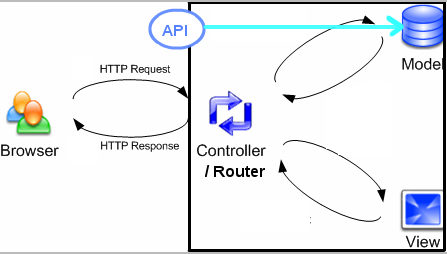

典型的 MVC 後端結構

- API 的使用情境 當使用者輸入網址， 向後端 (黑色框框部份） 傳送一個請求, 舉例來說： 向Yahoo 請求一個國內新聞頁面。 當 Controller 收到這個請求時， 會進行分析， 接著跟 Model取得資料、 跟 View取得 template (或靜態HTML)， 將兩者結合成一個完整的網頁 (這也是所謂的後端 Render), 最後把使用者路由到這個完整的網頁。

> MVC是一種軟體工程的開發概念， 分成3個部份：
> 1. Model, 與資料庫相關， 考慮資料如何存取
> 2. View, HTML, CSS, template
> 3. Controller, 處理使用者的請求， 取得資料， 回應給使用者
- 情境中 Yahoo 開放了一個 API ，透過這個窗口取得存在新聞資料庫的原始資料 （可能是 XML、純文字或是JSON格式）， 前端便可以寫一個template，並發出 XMLHttpRequest 訪問這個 API ，從 Yahoo 取回來的資料作 Render， 結合成一個完整的網頁。

## [網路通訊協定](https://bookdown.org/tpemartin/108-1-emajor/http.html) HTTPS (HTTP)

#### the **foundation of data communication** for the World Wide Web, where hypertext documents include hyperlinks to other resources that the user can easily access, for example by a **mouse click** or by tapping the screen. HTTP was developed to facilitate hypertext and the World Wide Web.

- Request methods: HTTP allows GET, PUT, POST, DELETE methods, etc. Among them,
  - GET: 取得資源（資料）
  - POST: 新增資源
- 我們平日所使用的瀏覽器是在進行GET請求(request)，得到訊息後瀏覽器再以我們可理解文字圖像呈現在眼前。
- Response content常見有以下三種格式：
1. 文字,XML：網址回傳一個文字檔時。
2. JSON：網址回傳一串文字資訊，如REST API。
3. Binary：網址回傳一個「非文字檔」。

```r
library(httr)
res <- GET("https://www.ntpu.edu.tw")
head(res$content) # 網頁內容（已編碼，要進一步還原成可理解內容）
```

```
## [1] 3c 48 54 4d 4c 3e
```

- 透過這串 URL，瀏覽器可以找到放在 Web Server 裡的 HTML 頁面，CSS 文檔，圖像等，然後瀏覽器再 rendering 出來給使用者看。
- curl (client URL): a command-line tool for **getting or sending data** including files **using URL** syntax. (讓個人電腦也可以進行各網路通訊協定的資訊交換。)
- R裡用**httr**來操作curl的套件。

```r
httpbinrhcurl <- "curl 'https://httpbin.org/headers' -H 'pragma: no-cache' -H 'accept-encoding: gzip, deflate, sdch' -H 'accept-language: en-US,en;q=0.8' -H 'upgrade-insecure-requests: 1' -H 'user-agent: Mozilla/5.0 (Macintosh; Intel Mac OS X 10_11_3) AppleWebKit/537.36 (KHTML, like Gecko) Chrome/49.0.2623.39 Safari/537.36' -H 'accept: text/html,application/xhtml+xml,application/xml;q=0.9,image/webp,*/*;q=0.8' -H 'cache-control: no-cache' -H 'referer: https://httpbin.org/' --compressed"
# 儲存response message
responseMessage <-
  httpbinrhcurl %>% # 原始curl語法
  stringr::str_c(collapse="") %>% # 把curl command合成一行
  stringr::str_replace_all("\\\\","") %>% # 去除換行符號 \
  straighten() %>% # 取出httr所需資訊
  make_req() %T>% # 翻譯成httr對應的HTTP verb呼叫方式
    {assign("requestMessage", ., envir = globalenv())}  %>% # 存在requestMessage
  {.[[1]]()}  # 執行request
```

```
## curl 'https://httpbin.org/headers' -H 'pragma: no-cache' -H 'accept-encoding: gzip, deflate, sdch' -H 'accept-language: en-US,en;q=0.8' -H 'upgrade-insecure-requests: 1' -H 'user-agent: Mozilla/5.0 (Macintosh; Intel Mac OS X 10_11_3) AppleWebKit/537.36 (KHTML, like Gecko) Chrome/49.0.2623.39 Safa…
```

[output not shown]

```r
# Request有時可能會失敗，但成功的話responseMessage$status_code會是200.
responseMessage$status_code
```

```
## [1] 200
```

```r
str(responseMessage)
```

```
## List of 10
##  $ url        : chr "https://httpbin.org/headers"
##  $ status_code: int 200
##  $ headers    :List of 7
##   ..$ date                            : chr "Wed, 18 Mar 2020 11:07:13 GMT"
##   ..$ content-type                    : chr "application/json"
##   ..$ content-length                  : chr "631"
##   ..$ connection                      : chr "keep-alive"
##   ..$ server                          : chr "gunicorn/19.9.0"
##   ..$ access-control-allow-origin     : chr "*"
##   ..$ access-control-allow-credentials: chr "true"
##   ..- attr(*, "class")= chr [1:2] "insensitive" "list"
##  $ all_headers:List of 1
##   ..$ :List of 3
##   .. ..$ status : int 200
##   .. ..$ version: chr "HTTP/1.1"
##   .. ..$ headers:List of 7
##   .. .. ..$ date                            : chr "Wed, 18 Mar 2020 11:07:13 GMT"
##   .. .. ..$ content-type                    : chr "application/json"
##   .. .. ..$ content-length                  : chr "631"
##   .. .. ..$ connection                      : chr "keep-alive"
##   .. .. ..$ server                          : chr "gunicorn/19.9.0"
##   .. .. ..$ access-control-allow-origin     : chr "*"
##   .. .. ..$ access-control-allow-credentials: chr "true"
##   .. .. ..- attr(*, "class")= chr [1:2] "insensitive" "list"
##  $ cookies    :'data.frame': 0 obs. of  7 variables:
##   ..$ domain    : logi(0)
##   ..$ flag      : logi(0)
##   ..$ path      : logi(0)
##   ..$ secure    : logi(0)
##   ..$ expiration: 'POSIXct' num(0)
##   ..$ name      : logi(0)
##   ..$ value     : logi(0)
##  $ content    : raw [1:631] 7b 0a 20 20 ...
##  $ date       : POSIXct[1:1], format: "2020-03-18 11:07:13"
##  $ times      : Named num [1:6] 0 0.000854 0.210167 0.612742 0.812958 ...
##   ..- attr(*, "names")= chr [1:6] "redirect" "namelookup" "connect" "pretransfer" ...
##  $ request    :List of 7
##   ..$ method    : chr "GET"
##   ..$ url       : chr "https://httpbin.org/headers"
##   ..$ headers   : Named chr [1:10] "application/json, text/xml, application/xml, */*" "" "no-cache" "gzip, deflate, sdch" ...
##   .. ..- attr(*, "names")= chr [1:10] "Accept" "Content-Type" "pragma" "accept-encoding" ...
##   ..$ fields    : NULL
##   ..$ options   :List of 4
##   .. ..$ useragent    : chr "libcurl/7.64.1 r-curl/4.3 httr/1.4.1"
##   .. ..$ post         : logi TRUE
##   .. ..$ postfieldsize: int 0
##   .. ..$ httpget      : logi TRUE
##   ..$ auth_token: NULL
##   ..$ output    : list()
##   .. ..- attr(*, "class")= chr [1:2] "write_memory" "write_function"
##   ..- attr(*, "class")= chr "request"
##  $ handle     :Class 'curl_handle' <externalptr>
##  - attr(*, "class")= chr "response"
```

## [XML document](https://bookdown.org/tpemartin/108-1-emajor/xml.html) with **XML** (Temple Lang and CRAN Team 2019)

- Extensible markup language
  - 描述**結構化資料**的語言
  - 處理XML檔案是**網頁Html爬蟲**的基礎
  - Components:
    - Markup 標記: labels that give the **text structure**
    - Content 內文: the actual text of the **document**
1. **Tags/label** correspond to general labels
- Start: `<breakfast_menu>`, `<price>`
- End: `</breakfast_menu>`,`</price>`
- Empty: `<line-break />`
2. **Elements** are specific examples of tags
- `<name>Belgian Waffles</name>`
3. **Attributes** are components of the label
- `<book category="web">` (**book標籤**底下附帶**category屬性**，其**值為web**)
- 舉例來說，若我們要用XML來記載課程的資訊，記載方式可以如下：`**"<course>DataScienceAndR</course><title>RDataEngineer-02-XML</title><author>Wush Wu</author>"**` 用**<>**框起來的文字代表**標籤**，上述文件中共有三個標籤：**course、title和author**。以course標籤為例，標籤的開始是`<course>`，結束則是`</course>`，會多一個“/”記號。透過這些標籤，電腦可以清楚的知道**DataScienceAndR代表的是course，RDataEngineer-02代表的是title，而Wush Wu代表的是author**。 對電腦而言，標籤與內容很清楚地被分開了，不會被混淆。
- XML的文件中，標籤可以有**結構關係**。 文件作範例： `'<tr> <th class="T11b" bgcolor="#ffdd83" align="left" valign="middle" width="200">廠商名稱</th> <td class="newstop" bgcolor="#EFF1F1">台灣翔登股份有限公司</td> </tr>'`
  - 這份文件中，將**tr**稱為th的**父標籤（parent）**，而**th與td**兩者都是tr的**子標籤（children）**
  - 在HTML網頁中，幾乎**所有的標籤都有父標籤**，**除了html**這個標籤以外。所以我們在處理HTML文件時，會稱呼這個標籤**html為整個文件的根（root）**。
- 挖掘網頁資訊的三步驟：1. 找到標籤(label) 2. 查詢屬性(attr) 3.檢查內容(文字、連結、圖片)。

```r
# install.packages("XML")
library(XML)
library(httr)
waterQ <- xmlParse(
  GET("http://data.taipei/opendata/datalist/datasetMeta/download?id=961ca397-4a59-45e8-b312-697f26b059dc&rid=190796c8-7c56-42e0-8068-39242b8ec927"), encoding = "UTF-8")
#因為XML套件處理http轉https的功能的不好，先使用GET()功能取用網址，再放入xmlParse()就不會有問題。
```

- 使用**xpathSApply()**函數搭配**XPath語法**取得指定標籤內的資料

```r
#取得所有"code_name"標籤內的資料
xpathSApply(waterQ, "//code_name", xmlValue)[1:10]
```

```
##  [1] "雙溪淨水場"               "衛理女中"
##  [3] "雙溪國小                " "華興加壓站"
##  [5] "長興淨水場"               "市政大樓"
##  [7] "市議會"                   "捷運忠孝復興站"
##  [9] "南港高工"                 "南港加壓站"
```

```r
#取得各監測站的經度
xpathSApply(waterQ, "//longitude", xmlValue)[1:10]
```

```
##  [1] "121.569433" "121.55231"  "121.563886" "121.544384" "121.547873"
##  [6] "121.563997" "121.561975" "121.54342"  "121.607462" "121.616217"
```

- 在**xpathSApply()**中，**參數path**對應到XPath，**XPath**是XML路徑語言（XML Path Language），基於XML的**樹狀**結構，提供在資料結構樹中找尋**節點**的能力，XPath語法可參考 [W3C Schools](https://www.w3schools.com/xml/xpath_syntax.asp)或是Google搜尋相關中文教學，如lxml、XPath。在此列舉幾個常用的語法:
> - //: 任意位置子結點資料,e.g.所有連結標籤: //a , /a
> - @: 屬性資料,e.g.所有連結標籤內的連結網址: //a/@href , /a[@href]

### Another package **xml2** (Wickham, Hester, and Ooms 2019)

```r
# install.packages("xml2")
library(xml2)
waterQ <- read_xml("http://data.taipei/opendata/datalist/datasetMeta/download?id=961ca397-4a59-45e8-b312-697f26b059dc&rid=190796c8-7c56-42e0-8068-39242b8ec927", encoding = "UTF-8")
xml_find_all(waterQ, "//code_name")
```

```
## {xml_nodeset (93)}
##  [1] <code_name>雙溪淨水場</code_name>
##  [2] <code_name>衛理女中</code_name>
##  [3] <code_name>雙溪國小                </code_name>
##  [4] <code_name>華興加壓站</code_name>
##  [5] <code_name>長興淨水場</code_name>
##  [6] <code_name>市政大樓</code_name>
##  [7] <code_name>市議會</code_name>
##  [8] <code_name>捷運忠孝復興站</code_name>
##  [9] <code_name>南港高工</code_name>
## [10] <code_name>南港加壓站</code_name>
## [11] <code_name>挹翠加壓站</code_name>
## [12] <code_name>敦化國中                </code_name>
## [13] <code_name>信義運動中心</code_name>
## [14] <code_name>信義區公所</code_name>
## [15] <code_name>大安運動中心</code_name>
## [16] <code_name>南港運動中心</code_name>
## [17] <code_name>公館淨水場</code_name>
## [18] <code_name>捷運台北車站</code_name>
## [19] <code_name>捷運中正紀念堂站</code_name>
## [20] <code_name>萬華國中</code_name>
## ...
```

- 使用**xml_find_all()**以及**xml_text()**取得指定標籤內的資料：

```r
#取得所有"code_name"標籤內的資料
code_name <- xml_find_all(waterQ, "//code_name") %>%
  xml_text()
code_name[1:10]
```

```
##  [1] "雙溪淨水場"               "衛理女中"
##  [3] "雙溪國小                " "華興加壓站"
##  [5] "長興淨水場"               "市政大樓"
##  [7] "市議會"                   "捷運忠孝復興站"
##  [9] "南港高工"                 "南港加壓站"
```

```r
#取得各監測站的經度longitude
longitude <- xml_find_all(waterQ, "//longitude") %>%
  xml_text()
longitude[1:10]
```

```
##  [1] "121.569433" "121.55231"  "121.563886" "121.544384" "121.547873"
##  [6] "121.563997" "121.561975" "121.54342"  "121.607462" "121.616217"
```

- 以上兩種套件均可完成**XML檔案的處理**，可依喜好選擇套件.

## 網頁爬蟲 Webscraping

- 由於不是每個網站都提供API，但網頁上卻有你想要分析的資料（像是ptt推文！？），除了人工複製貼上以外，也可以將網頁處理程式化，以**程式化**的方式**擷取網頁資料**就叫做**網頁爬蟲（Webscraping）**。
- 在R中可以
  1. 直接把**HTML檔案當作XML檔案處理** (fail now)
  2. 使用**rvest** (Wickham 2019a) package**輔助爬蟲**程式撰寫(裡面用到**CSS語法**)
- 此外，網頁爬蟲可能耗費很多網頁流量和資源，所以在許多網站被視為非法行為，如果一次讀太多太快，很可能被鎖IP。

```r
#以東華應數系網站為例，可直接逐行讀取 readLines()
# readLines(file("https://am.ndhu.edu.tw/", encoding = "UTF-8"), n = 10)
htmlCode <- readLines(file("https://am.ndhu.edu.tw/p/412-1038-2920.php?Lang=zh-tw", encoding = "UTF-8"))
htmlCode[1:10]
```

```
##  [1] "<!DOCTYPE html>"
##  [2] "<html lang=\"zh-tw\">"
##  [3] "<head>"
##  [4] "<meta http-equiv=\"Content-Type\" content=\"text/html; charset=utf-8\">"
##  [5] "<meta http-equiv=\"X-UA-Compatible\" content=\"IE=edge,chrome=1\" />"
##  [6] "<meta name=\"viewport\" content=\"initial-scale=1.0, user-scalable=1, minimum-scale=1.0, maximum-scale=3.0\">"
##  [7] "<meta name=\"apple-mobile-web-app-capable\" content=\"yes\">"
##  [8] "<meta name=\"apple-mobile-web-app-status-bar-style\" content=\"black\">"
##  [9] "<meta name=\"keywords\" content=\"請填寫網站關鍵記事，用半角逗號(,)隔開\" />"
## [10] "<meta name=\"description\" content=\"請填寫網站簡述\" />"
```

```r
str(htmlCode)
```

```
##  chr [1:1436] "<!DOCTYPE html>" "<html lang=\"zh-tw\">" "<head>" ...
```

```r
grep("<a href=", htmlCode, value = T)[1:6]
```

```
## [1] "<a href=\"#start-C\" class=\"focusable\" title=\"跳到主要內容區塊\">跳到主要內容區塊</a>"
## [2] "\t\t\t\t<li   id=\"Hln_3047\" class=\"dropdown\"><a class=\"dropdown-toggle\" data-toggle=\"dropdown\" href=\"javascript:void(0)\" title=\"招生\">招生</a><ul class=\"dropdown-menu\"><li  id=\"Hln_3048\"><a href=\"/p/412-1038-17033.php?Lang=zh-tw\" title=\"招生宣言\">招生宣言</a></li><li  id=\"Hln_3049\"…
## [3] "\t\t\t\t<li   id=\"Hln_3052\" class=\"dropdown\"><a class=\"dropdown-toggle\" data-toggle=\"dropdown\" href=\"javascript:void(0)\" title=\"簡介\">簡介</a><ul class=\"dropdown-menu\"><li  id=\"Hln_3053\"><a href=\"/p/412-1038-4351.php?Lang=zh-tw\" title=\"歷史沿革\">歷史沿革</a></li><li  id=\"Hln_3054\">…
## [4] "\t\t\t\t<li   id=\"Hln_3059\" class=\"dropdown\"><a class=\"dropdown-toggle\" data-toggle=\"dropdown\" href=\"javascript:void(0)\" title=\"成員\">成員</a><ul class=\"dropdown-menu\"><li  id=\"Hln_3060\"><a href=\"/p/412-1038-2920.php?Lang=zh-tw\" title=\"師資\">師資</a></li><li  id=\"Hln_3061\"><a h…
## [5] "\t\t\t\t<li   id=\"Hln_3423\" class=\"dropdown\"><a class=\"dropdown-toggle\" data-toggle=\"dropdown\" href=\"javascript:void(0)\" title=\"課程資訊\">課程資訊</a><ul class=\"dropdown-menu\"><li  id=\"Hln_3424\"><a href=\"/p/412-1038-6069.php?Lang=zh-tw\" title=\"聯合微積分教學\">聯合微積分教學</a></li><li  id=\"H…
## [6] "\t\t\t\t<li   id=\"Hln_3582\" class=\"dropdown\"><a class=\"dropdown-toggle\" data-toggle=\"dropdown\" href=\"/p/412-1038-3013.php?Lang=zh-tw\" title=\"學程化及未來方向\">學程化及未來方向</a><ul class=\"dropdown-menu\"><li  id=\"Hln_3583\"><a href=\"/p/412-1038-3015.php?Lang=zh-tw\" title=\"學程化\">學程化</a></l…
```

```r
ndhuAM <- read_html("https://am.ndhu.edu.tw/p/412-1038-2920.php?Lang=zh-tw")
xml_find_all(ndhuAM, "//html")
```

```
## {xml_nodeset (1)}
## [1] <html lang="zh-tw">\n<head>\n<meta http-equiv="Content-Type" content="tex ...
```

```r
xml_find_all(ndhuAM, "//*[contains(concat(' ', @class, ' '), concat(' ', 'mcol',' '))]") %>% xml_text()
```

```
## [1] "\n\t\t\t\t\t\n\t\t\t\t\t\t\n\t\t\t\t\t\t\n\t\t\t\t\t\t\n\n\n\n\n\t師資\n\n         \n\n\n\n\n\t\n\t\t\n \t\t\n\t\t\n\t\t\n\t\t\n\t\n\t\n\t\t\n\t\n\t\n\t\n\n\n\n\n\n\n\t\t\n\t\n\n\n\n\n\n\n\t\n\t\n\t\t\n\t\t\n\n標題\n\n\t\t職稱\n\n\t\t研究領域\n\n\t\t電話\n\n\t\tE-MAIL\n\n\t\n\t\t\t\n\t\t\t\t\n\t\t\t\t王立…
```

```r
# #或是使用XML工具分析擷取網頁 (XML package)，使用方法與XML檔案處理方法類似，搭配XPath語言，篩選所需資料
# html <- htmlParse("https://am.ndhu.edu.tw/")
# xpathSApply(html, "//ul", xmlValue)
# xpathSApply(html, "//span[@class='ptname ']", xmlValue)
```

### **rvest**(Wickham 2019a) package是R中最常使用的爬蟲套件

```r
# YahooNewsurl <- "https://tw.news.yahoo.com/topic/yahoo-today"
# read_html(YahooNewsurl) %>% html_nodes("#Col1-0-TopicWrapper-Proxy")%>% html_text()
# read_html(YahooNewsurl) %>% html_nodes("#Col1-0-TopicWrapper-Proxy div>div>span")%>% html_text()
# read_html(YahooNewsurl) %>% html_nodes(xpath = "//*[@id='ad-34813707356']")
# news_title <- read_html(YahooNewsurl) %>% html_nodes(".Mb(5px)") %>% html_text()
# news_url <- read_html(YahooNewsurl) %>% html_nodes(".tpl-title a") %>% html_attr("href")
# Yahoo_news <- data.frame(title = news_title, url=news_url)
# head(Yahoo_news)
```

- rvest套件，經由以下步驟進行網站解析：
  1. 使用read_html(“欲擷取的網站網址”)讀取網頁
  2. 使用html_nodes()擷取所需內容 (條件為CSS或xpath標籤)
  3. 使用html_text()處理/清洗擷取內容，留下需要的資料
  4. 使用html_attr()擷取資料參數（如連結url）

```r
Newsurl <- "https://www.twreporter.org/a/laughing-gas-nitrous-oxid-substance-abuse-hurt-youth-health"
articlebody <- read_html(Newsurl) %>%
  html_nodes("#article-body div") %>% html_text()
article <- data.frame(content = articlebody)
```

### CSS language

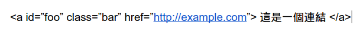

```r
Newsurl <- "https://www.twreporter.org/a/laughing-gas-nitrous-oxid-substance-abuse-hurt-youth-health"
articlebody <- read_html(Newsurl) %>%
  html_nodes("#article-body p") %>% html_text()
article <- data.frame(content = articlebody)
head(article)
```

```
##                                                                                                                                                                                                                                                                content
## 1 俗稱笑氣的一氧化二氮（N2O）原是半導體和食品加工等工業製程中，不可或缺的氣體原料，但這些年，原料卻悄悄流入市面，並被包裝成「派對助興」的催化劑。這無色微甜的便宜氣體，看似沒有立即成癮性，但2019年長庚醫院研究團隊發表報告，確診多名青少年因吸食笑氣而癱瘓的案例。
## 2                                                                                                                                               究竟笑氣為何在青少年間「流行」和被濫用？接手治療的醫師們怎麼看待笑氣在台灣被輕忽的危險，以及對青少年身心帶來的影響？
## 3                                                                                                                                                                                                 「我很喜歡那種ㄎㄧㄤ ㄎㄧㄤ的、很放鬆，可以暫時不想事情的感覺。」
## 4                                                       21歲的小柔（化名）曾經很努力戒掉過大麻、海洛因，相信自己不會再掉入吸毒的陷阱裡，「笑氣與毒品不同啊，」又不是違禁品、也不會被警察抓，她和朋友都這樣想。但這一次，為了幾秒鐘的放鬆，她付出的代價，是險些癱瘓。
## 5                                                                                                                                                                                                            笑氣對他們來說，不過就像是菸酒，只是聚會時的助興工具。
## 6                                     一年多前，小柔迷上交友軟體，認識了一群愛吸食笑氣的朋友。初次聚會，小柔回憶，她看著朋友將氣球套在笑氣鋼瓶的氣嘴上，灌成比一般氣球大一倍的「笑氣氣球」。因為好奇，她跟著朋友將氣球放入口中，吸一次氣，竟迎來一陣短暫麻痺的快感。
```

```r
articlebody <- read_html(Newsurl) %>%
  html_nodes("#article-body") %>% html_nodes(".body__StyledParagraph-dwuu2m-16") %>% html_text()
articleB <- data.frame(content = articlebody)
head(articleB)
```

```
##                                                                                                                                                                                                                            content
## 1                                                                                                                                                             「我很喜歡那種ㄎㄧㄤ ㄎㄧㄤ的、很放鬆，可以暫時不想事情的感覺。」
## 2                   21歲的小柔（化名）曾經很努力戒掉過大麻、海洛因，相信自己不會再掉入吸毒的陷阱裡，「笑氣與毒品不同啊，」又不是違禁品、也不會被警察抓，她和朋友都這樣想。但這一次，為了幾秒鐘的放鬆，她付出的代價，是險些癱瘓。
## 3                                                                                                                                                                        笑氣對他們來說，不過就像是菸酒，只是聚會時的助興工具。
## 4 一年多前，小柔迷上交友軟體，認識了一群愛吸食笑氣的朋友。初次聚會，小柔回憶，她看著朋友將氣球套在笑氣鋼瓶的氣嘴上，灌成比一般氣球大一倍的「笑氣氣球」。因為好奇，她跟著朋友將氣球放入口中，吸一次氣，竟迎來一陣短暫麻痺的快感。
## 5                                  在酒店上班的小柔，面對同行競爭與惡言雜語，心中委屈與負面情緒無法發洩時，她便想起那幾秒鐘的放鬆感。「面對那些謠言，好像辯解也不是，不辯解也不對，因為沒人可以講，就想到可以靠著笑氣（排解）。」
## 6                                                               在那個「忘憂」的世界裡，不必清醒地面對挫折，吸了就睡、醒了再吸，最多一天可以吸掉10公斤的笑氣，再倒頭大睡10多個小時。連續幾天後，她發現自己站不穩，無法正常走路。
```

```r
articlebody <- read_html(Newsurl) %>%
  html_nodes("#article-body") %>% html_nodes("h1") %>% html_text()
articleC <- data.frame(content = articlebody)
head(articleC)
```

```
##                                      content
## 1 從ㄎㄧㄤ掉變癱掉：「毒害」年輕人的笑氣濫用
## 2                     掉進笑氣陷阱的青少年們
## 3                           被低估的「毒害」
## 4            將笑氣列為毒品，能解決問題嗎？
```